# tDCS1

Prefrontal tDCS Enhances Visual Metacognition

Kwon, Hong, Eom, & Yi (2022)

2022-01-26

```r
set.seed(12345) # for reproducibility

pacman::p_load(tidyverse, knitr, psych, ggpubr)
pacman::p_load(afex, emmeans, rstatix)
pacman::p_load_gh("thomasp85/patchwork", "RLesur/klippy", "mitchelloharawild/icons")

source('HmiscHelper.R')
# 210615. Rmisc::summarySEwithin은 mean of normalized를 리턴.
# 따라서 패키지를 쓰지 않고 위 R파일에 정의된, 같은 이름의 함수를 쓴다.
# Rmisc::summarySEwithin과 달리 정규화하지 않은 평균도 제공한다.
# dplyr와 충돌하지 않도록 plyr 함수들을 직접 부르도록 수정하였다.
# http://www.cookbook-r.com/Graphs/Plotting_means_and_error_bars_(ggplot2)/
# See also: https://github.com/ccoolbaugh/FrontPhysiol_Coolbaugh_Cooling_Protocol

options(knitr.kable.NA = '')
options(dplyr.summarise.inform=FALSE) # suppress warning in regards to regrouping
set_sum_contrasts() # see Singmann & Kellen (2020)

klippy::klippy()
```

```r
## Plots

# stat summary plot to 25% quartile and 75% quartile: https://bit.ly/3iFpV07
single_hori_plot <- function(df, X, xMin, xMax, xBy, xLab){
  df %>% ggplot(aes(x=1, y=X)) +
    geom_violin(width = .9, trim = TRUE) +
    ggbeeswarm::geom_quasirandom(dodge.width = 0.5, color = "blue", size = 3,
                                 alpha = 0.2, show.legend = FALSE) +
    # stat_summary(fun.data = "mean_cl_boot", color = "darkred", size = 1) +
    geom_pointrange(stat = "summary",
                    fun.min = function(z) {quantile(z,0.25)},
                    fun.max = function(z) {quantile(z,0.75)},
                    fun = median, color = "darkred", size = 1) +
    scale_y_continuous(breaks=seq(xMin,xMax,by=xBy)) +
    coord_flip(ylim = c(xMin, xMax), clip = "on") +
    labs(y = xLab) +
    theme_bw(base_size = 18) +
    theme(panel.grid.major = element_blank(),
          panel.grid.minor = element_blank(),
          axis.title.y = element_blank(),
          axis.ticks.y = element_blank(),
          axis.text.y = element_blank(),
          aspect.ratio = .3)
}

plot2x2spaghetti <- function(df, ylabel, yrange){
  df.w <- df %>% pivot_wider(id_cols = c('Group', 'SID'),
                             names_from = 'Session', values_from = V)

  p <- ggplot(data=df, aes(x = Group, y = V, fill = Session)) +
    geom_violin(width = 0.5, trim = TRUE) +
    geom_point(position=position_dodge(0.5),
               color="gray80", size=1.8, show.legend = FALSE) +
    geom_segment(data=filter(df.w, Group=="Real"), inherit.aes = FALSE,
                 aes(x=1-.12, y=filter(df.w, Group=="Real")$Pre,
                     xend=1+.12, yend=filter(df.w, Group=="Real")$Post),
                 color="gray80") +
    geom_segment(data=filter(df.w, Group=="Sham"), inherit.aes = FALSE,
                 aes(x=2-.12, y=filter(df.w, Group=="Sham")$Pre,
                     xend=2+.12, yend=filter(df.w, Group=="Sham")$Post),
                 color="gray80") +
    geom_pointrange(data=summarySEwithin(data = df, measurevar = "V", idvar = "SID",
                                         withinvars = "Session", betweenvars = "Group"),
                    aes(x = Group, ymin = V-ci, ymax = V+ci, group = Session),
                    position = position_dodge(0.5), color = "darkred", size = 1, show.legend = FALSE) +
    scale_fill_manual(values=c("#E69F00", "#56B4E9"),
                      labels=c("Pre", "Post")) +
    labs(x = "Group",
         y = ylabel,
         fill='Session') +
    theme_bw(base_size = 18) +
    theme(panel.grid.major = element_blank(),
          panel.grid.minor = element_blank())

  if(missing(yrange)){
    p
  } else {
    p + coord_cartesian(ylim = yrange, clip = "on")
  }
}


## Excluding Ss
rm_subject <- function(df, rx){
  for (i in rx){
    df <- df %>% filter(SID != i) %>% droplevels()
  }
  cat(sprintf('%d removed & %d left',
              length(unique(rx)),
              length(unique(df$SID))))
  return(df)
}
```

# 1 Data Inspection

가장 먼저 가외치를 결정한다.

## 1.1 Raw Data

```r
d <- read_csv('metaRDMmain.csv', show_col_types = FALSE)

d$Group <- factor(d$Group, levels=c(1,2), labels=c("Real","Sham"))
d$Session <- factor(d$Session, levels=c(1,2), labels=c("Pre","Post"))
d$TargLoc <- factor(d$TargLoc, levels=c(1,2), labels=c("L","R"))

unique(d$Resp)    # 0_no resp,
## [1] 1 2 0
unique(d$Correct)
## [1] 0 1
unique(d$Conf)    # 0, 6 = no response or multiple keys
## [1] 2 1 3 4 0 6
```

### 1.1.1 % No Response

반응이 입력되지 않은 시행의 비율을 계산하였다.

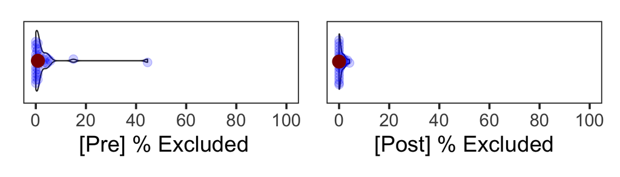

```r
# % excluded trials: 지각반응과 확신도 무반응/잘못된 버튼
d %>% filter(Session == 'Pre') %>%
  mutate(X = ifelse(Resp==0, 1, ifelse((Conf==0)|(Conf==5), 1, 0))) %>%
  group_by(SID) %>%
  summarise(Excl = mean(X)*100) %>%
  ungroup() %>%
  print(n = Inf) # Note #26
## # A tibble: 32 × 2
##      SID   Excl
##    <dbl>  <dbl>
##  1     1  4.17
##  2     2  3.33
##  3     3  0
##  4     4 15
##  5     5  0
##  6     6  5.83
##  7     7  0.833
##  8     8  0
##  9     9  1.67
## 10    10  0.833
## 11    11  1.25
## 12    12  2.92
## 13    13  0
## 14    14  0
## 15    15  0
## 16    16  1.67
## 17    17  0
## 18    18  0
## 19    19  0.833
## 20    20  0.833
## 21    21  4.58
## 22    22  0
## 23    23  0
## 24    24  0.417
## 25    25  0.833
## 26    26 44.6
## 27    27  5
## 28    28  0
## 29    29  0
## 30    30  0.417
## 31    31  0.833
## 32    32  3.75

d26 <- d %>% filter(SID == 26)
table(d26$Resp, d26$Session) # pre에서 약 50% 무반응
##
##     Pre Post
##   0 106    0
##   1 106  189
##   2  28   51

F1 <- d %>% filter(Session == 'Pre') %>%
  mutate(X = ifelse(Resp==0, 1, ifelse((Conf==0)|(Conf==5), 1, 0))) %>%
  group_by(SID) %>%
  summarise(Excl = mean(X)*100) %>%
  ungroup() %>%
  single_hori_plot(.$Excl, 0, 100, 20, " [Pre] % Excluded")

F2 <- d %>% filter(Session == 'Post') %>%
  mutate(X = ifelse(Resp==0, 1, ifelse((Conf==0)|(Conf==5), 1, 0))) %>%
  group_by(SID) %>%
  summarise(Excl = mean(X)*100) %>%
  ungroup() %>%
  single_hori_plot(.$Excl, 0, 100, 20, "[Post] % Excluded")

F1 + F2
```

26번 참가자는 `pre-tDCS` 시행 중 절반에서 시각판단 반응을 입력하지 않았다.

### 1.1.2 Mean Confidence

[figure not shown]

```r
F1 <- d %>% filter(Session == 'Pre') %>%
  filter(Resp > 0, Conf > 0, Conf < 5) %>%
  group_by(SID) %>%
  summarise(M = mean(Conf)) %>%
  ungroup() %>%
  single_hori_plot(.$M, 1, 4, 0.5, "[Pre] Mean Confidence")

F2 <- d %>% filter(Session == 'Pre') %>%
  filter(Resp > 0, Conf > 0, Conf < 5) %>%
  group_by(SID) %>%
  summarise(M = mean(Conf)) %>%
  ungroup() %>%
  single_hori_plot(.$M, 1, 4, 0.5, "[Post] Mean Confidence")

F1 + F2
```

### 1.1.3 Perceptual Accuracy

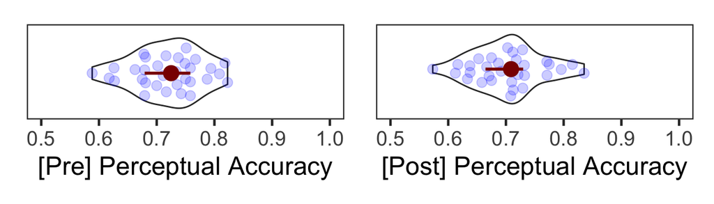

```r
F1 <- d %>% filter(Session == 'Pre') %>%
  filter(Resp > 0) %>%
  group_by(SID) %>%
  summarise(M = mean(Correct)) %>%
  ungroup() %>%
  single_hori_plot(.$M, 0.5, 1, .1, "[Pre] Perceptual Accuracy")

F2 <- d %>% filter(Session == 'Post') %>%
  filter(Resp > 0) %>%
  group_by(SID) %>%
  summarise(M = mean(Correct)) %>%
  ungroup() %>%
  single_hori_plot(.$M, 0.5, 1, .1, "[Post] Perceptual Accuracy")

F1 + F2
```

### 1.1.4 Motion Coherence

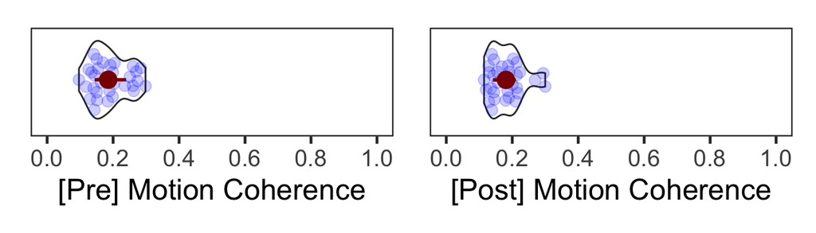

```r
F1 <- d %>% filter(Session == 'Pre') %>%
  filter(Resp > 0) %>%
  group_by(SID) %>%
  summarise(M = mean(Difficulty)) %>%
  ungroup() %>%
  single_hori_plot(.$M, 0, 1, .2, "[Pre] Motion Coherence")

F2 <- d %>% filter(Session == 'Post') %>%
  filter(Resp > 0) %>%
  group_by(SID) %>%
  summarise(M = mean(Difficulty)) %>%
  ungroup() %>%
  single_hori_plot(.$M, 0, 1, .2, "[Post] Motion Coherence")

F1 + F2
```

## 1.2 Matlab MLE Data

[Maniscalco](http://www.columbia.edu/~bsm2105/type2sdt/)의 코드를 사용하여 $d'$, meta-$d'$, M-ratio(meta-$d'/d'$)를 계산하였다. `trials2counts()` 함수와 `fit_meta_d_MLE()` 함수에 입력한 값들은 아래 코드와 같았다. 4점 척도에서 빈도가 0인 경우가 많아서, `fit_meta_d_MLE()` 도움말을 따라 2점 척도로 변환하였다. 여전히 빈도가 0인 점수들이 있으므로, [작은 수](https://bit.ly/3i3DJkE)(adj_f = 1/(length(nR_S1)) = 0.25)를 [모든 값](https://bit.ly/3uwHp0U)에 더해주었다

```matlab
% 원자료: metaRDMmain.csv

stimID = TargLoc - 1;
response = Resp - 1;
rating = Conf;
nRatings = 2;
cellpad = 1; # 확신도 점수 빈도 = 0인 사례를 보정.

[nR_S1, nR_S2] = trials2counts(stimID, response, rating, nRatings, cellpad);

fit = fit_meta_d_MLE(nR_S1, nR_S2);

% 출력자료: tDCS1_estimated.csv
```

```r
mtb2 <- read_csv('tDCS1_estimated_2scale.csv') %>% filter(SID!= 26)
## Rows: 32 Columns: 15
## ── Column specification ────────────────────────────────────────────────────────
## Delimiter: ","
## dbl (15): #, SID, Group, p1da, p1meta_da, p1M_diff, p1M_ratio, p1meta_ca, ex...
##
## ℹ Use `spec()` to retrieve the full column specification for this data.
## ℹ Specify the column types or set `show_col_types = FALSE` to quiet this message.

selectMtb <- function(mtb, V1, V2){
  df <- mtb %>% select(Group, SID, all_of(V1), all_of(V2)) %>%
    pivot_longer(cols = c(all_of(V1), all_of(V2)), names_to = "Session", values_to = "V") %>%
    mutate(Group = fct_recode(as_factor(Group), "Real" = '1', "Sham" = '2')) %>%
    mutate(Session = fct_recode(Session, "Pre" = V1, "Post" = V2))
  return(df)
}
```

### 1.2.1 Type-1 Accuracy: d’

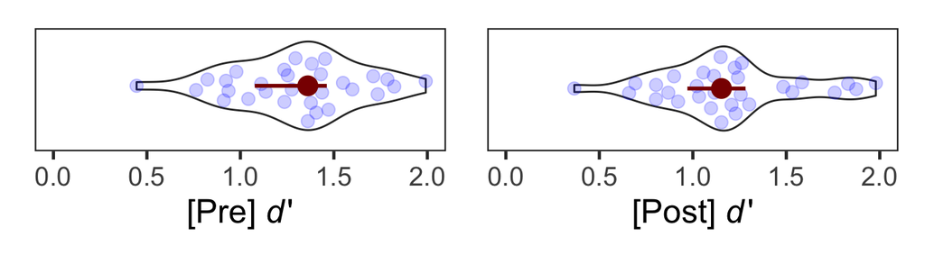

```r
# d'
td <- mtb2 %>% selectMtb('p1da', 'p2da')

F1 <- td %>% filter(Session == 'Pre') %>%
  single_hori_plot(.$V, 0, 2, .5, expression(paste("[Pre] ", italic(d), "'")))
F2 <- td %>% filter(Session == 'Post') %>%
  single_hori_plot(.$V, 0, 2, .5, expression(paste("[Post] ", italic(d), "'")))
F1 + F2
```

### 1.2.2 Type-2 Accuracy: Meta-d’

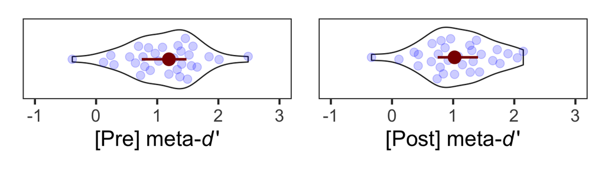

```r
# meta-d'
tm <- mtb2 %>% selectMtb('p1meta_da', 'p2meta_da')

F1 <- tm %>% filter(Session == 'Pre') %>%
  single_hori_plot(.$V, -1, 3, 1, expression(paste("[Pre] meta-", italic(d), "'")))
F2 <- tm %>% filter(Session == 'Post') %>%
  single_hori_plot(.$V, -1, 3, 1, expression(paste("[Post] meta-", italic(d), "'")))
F1 + F2
```

### 1.2.3 M-Ratio (Meta-d’/d’)

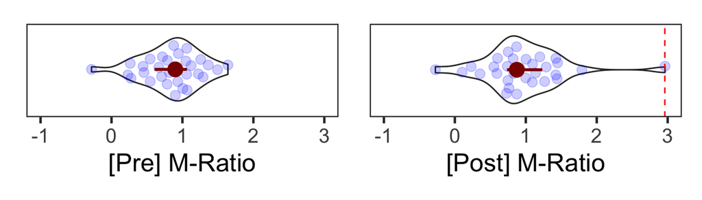

```r
# meta-ratio
tr <- mtb2 %>% selectMtb('p1M_ratio', 'p2M_ratio')

tr %>% filter(Session == 'Pre') %>%
  mutate(lbound = mean(.$V) - 3*sd(.$V),
         ubound = mean(.$V) + 3*sd(.$V)) %>%
  mutate(Outlier = (V < lbound)|(V > ubound)) %>%
  filter(Outlier == TRUE) %>%
  droplevels()
## # A tibble: 0 × 7
## # … with 7 variables: Group <fct>, SID <dbl>, Session <fct>, V <dbl>,
## #   lbound <dbl>, ubound <dbl>, Outlier <lgl>

tr %>% filter(Session == 'Post') %>%
  mutate(lbound = mean(.$V) - 3*sd(.$V),
         ubound = mean(.$V) + 3*sd(.$V)) %>%
  mutate(Outlier = (V < lbound)|(V > ubound)) %>%
  filter(Outlier == TRUE) %>%
  droplevels()
## # A tibble: 1 × 7
##   Group   SID Session     V lbound ubound Outlier
##   <fct> <dbl> <fct>   <dbl>  <dbl>  <dbl> <lgl>
## 1 Sham      8 Post     2.96 -0.754   2.67 TRUE

F1 <- tr %>% filter(Session == 'Pre') %>%
  single_hori_plot(.$V, -1, 3, 1, '[Pre] M-Ratio')
F2 <- tr %>% filter(Session == 'Post') %>%
  single_hori_plot(.$V, -1, 3, 1, '[Post] M-Ratio') +
  geom_hline(yintercept=2.96, linetype='dashed', color='red', size=0.5)
F1 + F2
```

## 1.3 Subject Exclusion

참가자 26번과 8번을 최종분석에서 제외한다(`Real` 집단 16명, `Sham` 집단 14명).

```r
d2 <- d %>% rm_subject(c(8, 26)) %>% filter(Resp > 0, Conf > 0, Conf < 5)
## 2 removed & 30 left
mtb2 <- mtb2 %>% rm_subject(c(8, 26))
## 2 removed & 30 left
```

# 2 Type-1 Accuracy

모든 조건의 정확도는 대체로 1-up-2-down 계단법의 기대값인 70.7% 가까이에서 유지되었다([Levitt, 1971](https://asa.scitation.org/doi/abs/10.1121/1.1912375)).

```r
accuracy <- d2 %>%
    group_by(Group, Session, SID) %>%
    summarize(V = mean(Correct)*100) %>%
    ungroup()

accuracy %>%
    group_by(Group, Session) %>%
    summarize(Accuracy = mean(V)) %>%
    ungroup() %>%
    pivot_wider(names_from = 'Session', values_from = 'Accuracy') %>%
    kable(digits = 4, caption = 'Mean Type-1 Accuracy')
```

Mean Type-1 Accuracy

| Group | Pre | Post |
| --- | --- | --- |
| Real | 70.6339 | 70.2332 |
| Sham | 73.6954 | 71.3001 |

```r
accuracy %>%
    aov_ez(id = 'SID', dv = 'V',
                 between = 'Group', within = 'Session') %>%
    anova(es="pes") %>%
    kable(digits = 4, caption = 'Type-1 Accuracy ANOVA')
```

Type-1 Accuracy ANOVA

|  | num Df | den Df | MSE | F | pes | Pr(>F) |
| --- | --- | --- | --- | --- | --- | --- |
| Group | 1 | 28 | 37.2686 | 1.7073 | 0.0575 | 0.2020 |
| Session | 1 | 28 | 30.3294 | 0.9624 | 0.0332 | 0.3350 |
| Group:Session | 1 | 28 | 30.3294 | 0.4897 | 0.0172 | 0.4898 |

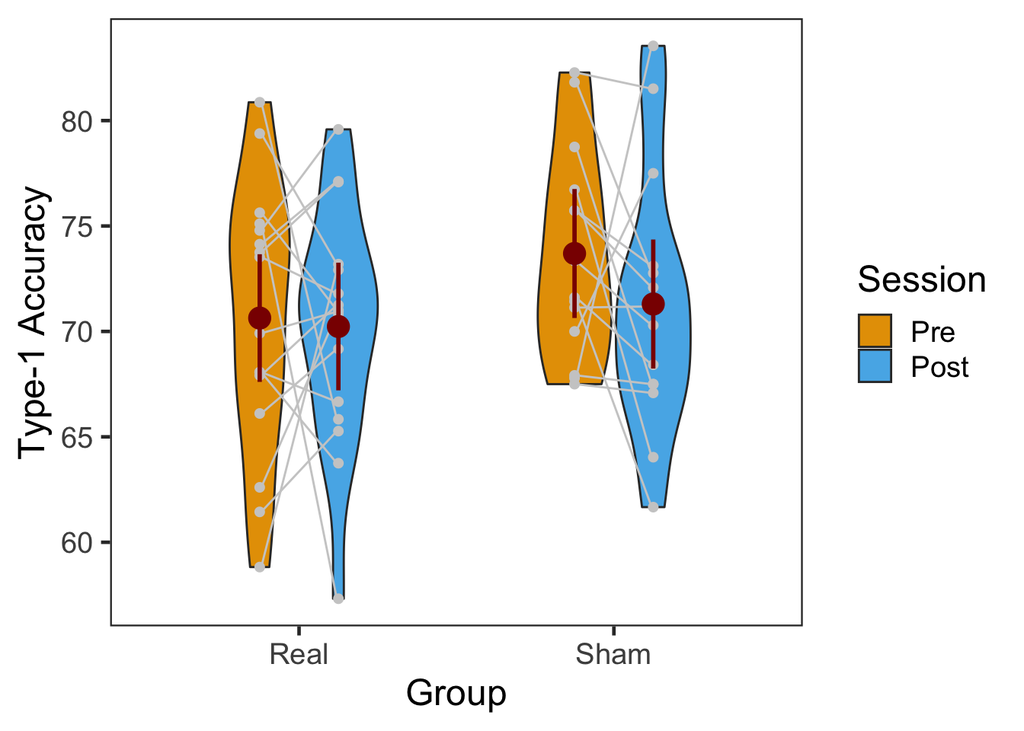

```r
plot2x2spaghetti(accuracy, "Type-1 Accuracy")
```

# 3 Motion Coherence

계단법에 의해 정확도가 고정되었으므로 tDCS가 지각판단에 영향을 주었다면, 그 효과는 점 운동의 일관성 수준(coherence levels)에 반영되었을 것이다. 그러나 일관성 수준의 조건간 차이는 주목할 만큼 크지 않았다

```r
coherence <- d2 %>%
    group_by(Group, Session, SID) %>%
    summarize(V = mean(Difficulty)) %>%
    ungroup()

coherence %>%
    group_by(Group, Session) %>%
    summarize(Coherence = mean(V)) %>%
    ungroup() %>%
    pivot_wider(names_from = 'Session', values_from = 'Coherence') %>%
    kable(digits = 4, caption = 'Mean Motion Coherence')
```

Mean Motion Coherence

| Group | Pre | Post |
| --- | --- | --- |
| Real | 0.1754 | 0.1755 |
| Sham | 0.2057 | 0.1886 |

```r
coherence %>%
    aov_ez(id = 'SID', dv = 'V',
                 between = 'Group', within = 'Session') %>%
    anova(es="pes") %>%
    kable(digits = 4, caption = 'Mean Motion Coherence ANOVA')
```

Mean Motion Coherence ANOVA

|  | num Df | den Df | MSE | F | pes | Pr(>F) |
| --- | --- | --- | --- | --- | --- | --- |
| Group | 1 | 28 | 0.0041 | 1.7005 | 0.0573 | 0.2028 |
| Session | 1 | 28 | 0.0013 | 0.7971 | 0.0277 | 0.3796 |
| Group:Session | 1 | 28 | 0.0013 | 0.8201 | 0.0285 | 0.3729 |

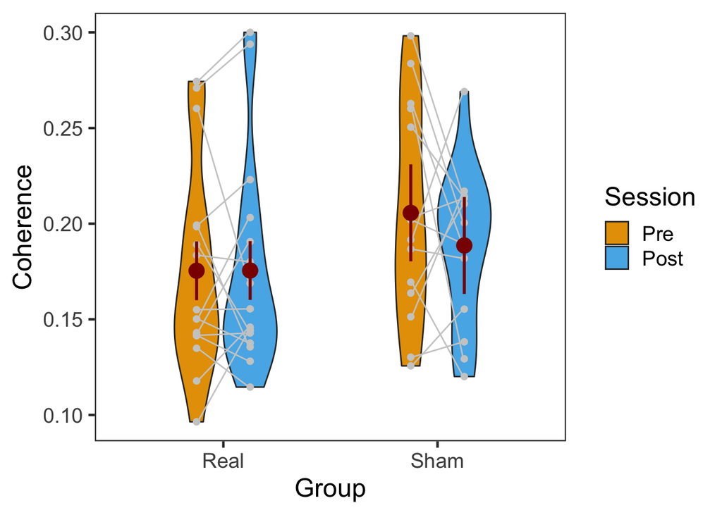

```r
plot2x2spaghetti(coherence, "Coherence")
```

# 4 Confidence

tDCS가 확신 수준에 영향을 끼쳤는지 확인하기 위해 **평균 확신도** 점수를 분석하였다. 분석 결과, 눈에 띄는 효과는 없었다. (참고: 다른 지표들에 비해, 각 참가자의 평균 확신도 점수는 일정하게 유지되는 것으로 보인다. 신뢰구간이 작다.)

```r
confidence <- d2 %>% group_by(Group, Session, SID) %>%
  summarise(V = mean(Conf)) %>%
  ungroup()

confidence %>%
    group_by(Group, Session) %>%
    summarize(Confidence = mean(V)) %>%
    ungroup() %>%
    pivot_wider(names_from = 'Session', values_from = 'Confidence') %>%
    kable(digits = 4, caption = 'Mean Confidence')
```

Mean Confidence

| Group | Pre | Post |
| --- | --- | --- |
| Real | 2.2947 | 2.2701 |
| Sham | 2.7090 | 2.5926 |

```r
confidence %>%
    aov_ez(id = 'SID', dv = 'V',
                 between = 'Group', within = 'Session') %>%
    anova(es="pes") %>%
    kable(digits = 4, caption = 'Mean Confidence ANOVA')
```

Mean Confidence ANOVA

|  | num Df | den Df | MSE | F | pes | Pr(>F) |
| --- | --- | --- | --- | --- | --- | --- |
| Group | 1 | 28 | 0.5167 | 3.9219 | 0.1229 | 0.0576 |
| Session | 1 | 28 | 0.0457 | 1.6227 | 0.0548 | 0.2132 |
| Group:Session | 1 | 28 | 0.0457 | 0.6900 | 0.0240 | 0.4132 |

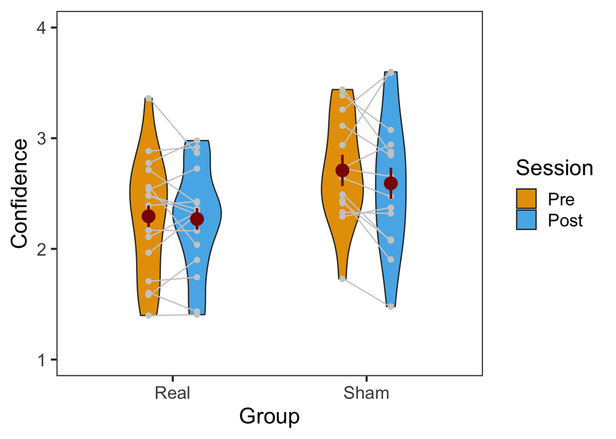

```r
plot2x2spaghetti(confidence, "Confidence", c(1,4))
```

# 5 d’

$d'$은 tDCS 영향을 전혀 받지 않았다.

```r
td <- mtb2 %>% selectMtb('p1da', 'p2da')

td %>% group_by(Group, Session) %>%
  summarise(Sensitivity = mean(V)) %>%
  ungroup() %>%
  pivot_wider(names_from = 'Session', values_from = 'Sensitivity') %>%
  kable(digits = 4, caption = 'Mean Sensitivity')
```

Mean Sensitivity

| Group | Pre | Post |
| --- | --- | --- |
| Real | 1.2115 | 1.1788 |
| Sham | 1.3662 | 1.2234 |

```r
td %>% aov_ez(id = 'SID', dv = 'V',
                            between = 'Group', within = 'Session') %>%
    anova(es="pes") %>%
    kable(digits = 4, caption = 'Sensitivity ANOVA')
```

Sensitivity ANOVA

|  | num Df | den Df | MSE | F | pes | Pr(>F) |
| --- | --- | --- | --- | --- | --- | --- |
| Group | 1 | 28 | 0.1192 | 1.2442 | 0.0425 | 0.2741 |
| Session | 1 | 28 | 0.1295 | 0.8871 | 0.0307 | 0.3543 |
| Group:Session | 1 | 28 | 0.1295 | 0.3488 | 0.0123 | 0.5595 |

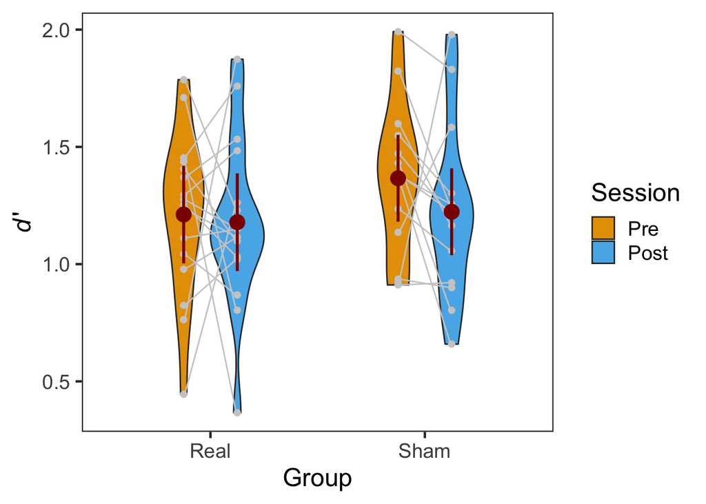

```r
td %>% plot2x2spaghetti(ylabel = expression(paste(italic(d), "'")))
```

참가자들의 $d'$이 두 세션에서 일정하게 유지되지 않았다는 점이 주목할만 하다. 본 실험 과제가 $d'$을 안정적으로 추정하지 못한다는 것을 알 수 있다.

# 6 Meta-d’

Meta-$d'$도 tDCS 영향을 받지 않았다.

```r
## meta-d'
tm <- mtb2 %>% selectMtb('p1meta_da', 'p2meta_da')

tm %>% group_by(Group, Session) %>%
  summarise(MetaSensitivity = mean(V)) %>%
  ungroup() %>%
  pivot_wider(names_from = 'Session', values_from = 'MetaSensitivity') %>%
  kable(digits = 4, caption = 'Mean Meta-Sensitivity')
```

Mean Meta-Sensitivity

| Group | Pre | Post |
| --- | --- | --- |
| Real | 0.8537 | 0.9993 |
| Sham | 1.3540 | 1.0626 |

```r
tm %>% aov_ez(id = 'SID', dv = 'V',
                            between = 'Group', within = 'Session') %>%
    anova(es="pes") %>%
    kable(digits = 4, caption = 'Meta-Sensitivity ANOVA')
```

Meta-Sensitivity ANOVA

|  | num Df | den Df | MSE | F | pes | Pr(>F) |
| --- | --- | --- | --- | --- | --- | --- |
| Group | 1 | 28 | 0.4311 | 2.7511 | 0.0895 | 0.1083 |
| Session | 1 | 28 | 0.1833 | 0.4336 | 0.0152 | 0.5156 |
| Group:Session | 1 | 28 | 0.1833 | 3.8888 | 0.1219 | 0.0586 |

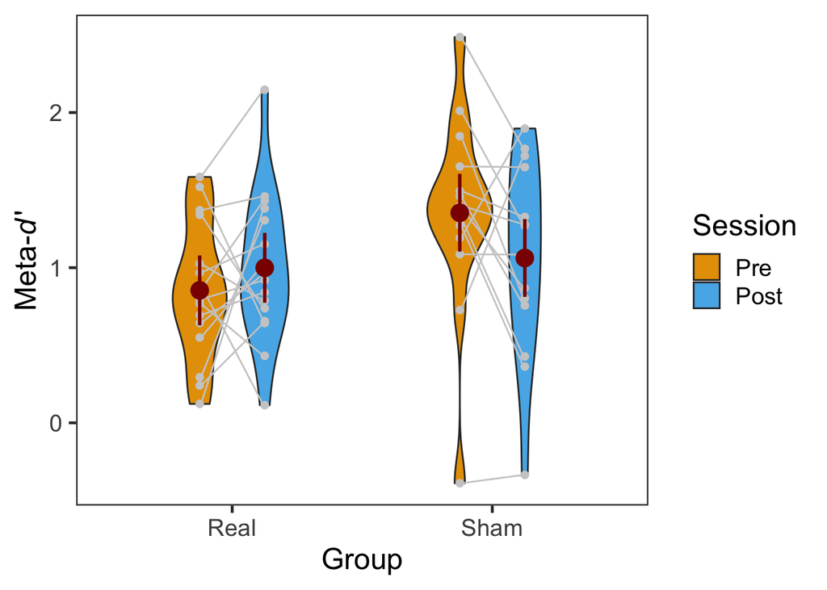

```r
tm %>% plot2x2spaghetti(ylabel = expression(paste("Meta-", italic(d), "'")))
```

$d'$에서와 마찬가지로, 참가자들의 meta-$d'$이 두 세션에서 일정하게 유지되지 않았다.

# 7 M-Ratio (Meta-d’/d’)

메타인지 효율성 지표에서 이원 상호작용이 유의미하였다. `Real` 집단의 메타인지 효율성이 유의미하게 향상되었다.

```r
## Ratio
tr <- mtb2 %>% selectMtb('p1M_ratio', 'p2M_ratio')

tr %>% group_by(Group, Session) %>%
  summarise(Mratio = mean(V)) %>%
  ungroup() %>%
  pivot_wider(names_from = 'Session', values_from = 'Mratio') %>%
  kable(digits = 4, caption = 'Mean M-Ratio')
```

Mean M-Ratio

| Group | Pre | Post |
| --- | --- | --- |
| Real | 0.6886 | 0.9027 |
| Sham | 1.0169 | 0.8826 |

```r
tmp <- tr %>% aov_ez(id = 'SID', dv = 'V',
                     between = 'Group', within = 'Session')

tmp %>%
    anova(es="pes") %>%
    kable(digits = 4, caption = 'M-Ratio ANOVA')
```

M-Ratio ANOVA

|  | num Df | den Df | MSE | F | pes | Pr(>F) |
| --- | --- | --- | --- | --- | --- | --- |
| Group | 1 | 28 | 0.2833 | 1.2526 | 0.0428 | 0.2726 |
| Session | 1 | 28 | 0.0691 | 0.3437 | 0.0121 | 0.5624 |
| Group:Session | 1 | 28 | 0.0691 | 6.5588 | 0.1898 | 0.0161 |

```r
tmp2 <- tmp %>% emmeans::emmeans(pairwise ~ Session | Group)
tmp2$contrasts %>% kable(digits = 4, caption = 'Post hoc')
```

Post hoc

| contrast | Group | estimate | SE | df | t.ratio | p.value |
| --- | --- | --- | --- | --- | --- | --- |
| Pre - Post | Real | -0.2141 | 0.0929 | 28 | -2.3036 | 0.0289 |
| Pre - Post | Sham | 0.1343 | 0.0993 | 28 | 1.3520 | 0.1872 |

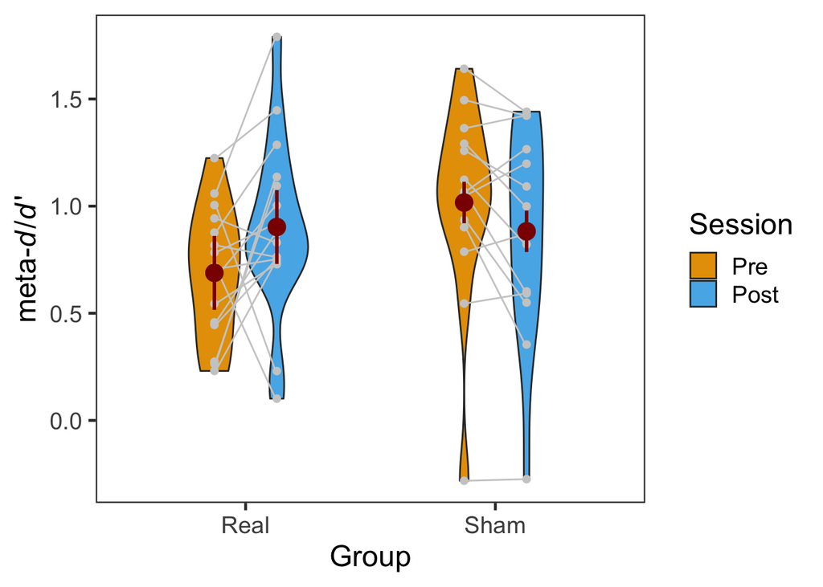

```r
tr %>% plot2x2spaghetti(ylabel = expression(paste("meta-", italic(d), "/", italic(d), "'")))
```

# 8 Demographic Info

두 명을 제외하고 남은 참가자 30명의 집단별 연령과 성비를 분석한다.

```r
demo <- read.csv('tDCS1_demographic.csv', header = TRUE)
head(demo)
##   SN    Sex Group Age Excluded
## 1  1   Male  Real  25        0
## 2  7   Male  Real  25        0
## 3 10   Male  Real  24        0
## 4 23   Male  Real  27        0
## 5 27   Male  Real  28        0
## 6  4 Female  Real  22        0

demo <- demo %>% filter(Excluded == 0)
table(demo$Group, demo$Sex) %>%
  kable(caption = 'Group x Sex')
```

Group x Sex

|  | Female | Male |
| --- | --- | --- |
| Real | 11 | 5 |
| Sham | 7 | 7 |

```r
demo %>% group_by(Group) %>%
  summarise(M = mean(Age),
            SD = sd(Age)) %>%
  ungroup() %>%
  kable(digits = 2, caption = 'Group x Age')
```

Group x Age

| Group | M | SD |
| --- | --- | --- |
| Real | 23.44 | 2.45 |
| Sham | 23.86 | 2.57 |

$\chi^2$-검정에서 셀이 네 개이면 *p*가 작게 나와서 1종오류 가능성 높아지므로, 예이츠의 연속성 보정이 필요하다(`correct = TRUE`).

```r
# 카이제곱 검정
t <- table(demo$Group, demo$Sex)
chisq.test(t, correct = TRUE)
```

```
##
##  Pearson's Chi-squared test with Yates' continuity correction
##
## data:  t
## X-squared = 0.45201, df = 1, p-value = 0.5014
```

성별비의 집단차는 유의하지 않았다.

```r
t.test(data = demo,
       Age ~ Group,
       alternative = "two.sided",
       paired = FALSE,
       var.equal = TRUE)
```

```
##
##  Two Sample t-test
##
## data:  Age by Group
## t = -0.45782, df = 28, p-value = 0.6506
## alternative hypothesis: true difference in means between group Real and group Sham is not equal to 0
## 95 percent confidence interval:
##  -2.297230  1.457945
## sample estimates:
## mean in group Real mean in group Sham
##           23.43750           23.85714
```

연령의 집단차도 유의하지 않았다. 효과 크기는 아래와 같이 계산할 수 있다.

```r
# https://www.datanovia.com/en/lessons/t-test-effect-size-using-cohens-d-measure/
cohens_d(data = demo,
         Age ~ Group,
         var.equal = TRUE,
         hedges.correction = TRUE)
```

```
## # A tibble: 1 × 7
##   .y.   group1 group2 effsize    n1    n2 magnitude
## * <chr> <chr>  <chr>    <dbl> <int> <int> <ord>
## 1 Age   Real   Sham    -0.163    16    14 negligible
```

```r
# 표본크기가 50보다 작으면 hedge's corrected version (Hedges and Olkin 1985)
```

# 9 Session Info

```r
sessionInfo()
## R version 4.1.2 (2021-11-01)
## Platform: x86_64-apple-darwin17.0 (64-bit)
## Running under: macOS Big Sur 10.16
##
## Matrix products: default
## BLAS:   /Library/Frameworks/R.framework/Versions/4.1/Resources/lib/libRblas.0.dylib
## LAPACK: /Library/Frameworks/R.framework/Versions/4.1/Resources/lib/libRlapack.dylib
##
## locale:
## [1] en_US.UTF-8/en_US.UTF-8/en_US.UTF-8/C/en_US.UTF-8/en_US.UTF-8
##
## attached base packages:
## [1] stats     graphics  grDevices utils     datasets  methods   base
##
## other attached packages:
##  [1] icons_0.2.0       klippy_0.0.0.9500 patchwork_1.1.1   rstatix_0.7.0
##  [5] emmeans_1.7.2     afex_1.0-1        lme4_1.1-27.1     Matrix_1.4-0
##  [9] ggpubr_0.4.0      psych_2.1.9       knitr_1.37        forcats_0.5.1
## [13] stringr_1.4.0     dplyr_1.0.7       purrr_0.3.4       readr_2.1.1
## [17] tidyr_1.1.4       tibble_3.1.6      ggplot2_3.3.5     tidyverse_1.3.1
##
## loaded via a namespace (and not attached):
##  [1] ggbeeswarm_0.6.0    TH.data_1.1-0       minqa_1.2.4
##  [4] colorspace_2.0-2    ggsignif_0.6.3      ellipsis_0.3.2
##  [7] estimability_1.3    fs_1.5.2            rstudioapi_0.13
## [10] farver_2.1.0        bit64_4.0.5         fansi_1.0.2
## [13] mvtnorm_1.1-3       lubridate_1.8.0     xml2_1.3.3
## [16] codetools_0.2-18    splines_4.1.2       mnormt_2.0.2
## [19] jsonlite_1.7.3      nloptr_1.2.2.3      broom_0.7.11
## [22] dbplyr_2.1.1        compiler_4.1.2      httr_1.4.2
## [25] backports_1.4.1     assertthat_0.2.1    fastmap_1.1.0
## [28] cli_3.1.1           htmltools_0.5.2     tools_4.1.2
## [31] lmerTest_3.1-3      coda_0.19-4         gtable_0.3.0
## [34] glue_1.6.1          reshape2_1.4.4      rappdirs_0.3.3
## [37] Rcpp_1.0.8          carData_3.0-5       cellranger_1.1.0
## [40] jquerylib_0.1.4     vctrs_0.3.8         nlme_3.1-155
## [43] xfun_0.29           rvest_1.0.2         lifecycle_1.0.1
## [46] pacman_0.5.1        MASS_7.3-55         zoo_1.8-9
## [49] scales_1.1.1        vroom_1.5.7         hms_1.1.1
## [52] parallel_4.1.2      sandwich_3.0-1      yaml_2.2.1
## [55] sass_0.4.0          stringi_1.7.6       highr_0.9
## [58] boot_1.3-28         rlang_0.4.12        pkgconfig_2.0.3
## [61] evaluate_0.14       lattice_0.20-45     labeling_0.4.2
## [64] bit_4.0.4           tidyselect_1.1.1    plyr_1.8.6
## [67] magrittr_2.0.1      R6_2.5.1            generics_0.1.1
## [70] multcomp_1.4-18     DBI_1.1.2           pillar_1.6.4
## [73] haven_2.4.3         withr_2.4.3         survival_3.2-13
## [76] abind_1.4-5         modelr_0.1.8        crayon_1.4.2
## [79] car_3.0-12          utf8_1.2.2          tmvnsim_1.0-2
## [82] tzdb_0.2.0          rmarkdown_2.11      grid_4.1.2
## [85] readxl_1.3.1        reprex_2.0.1        digest_0.6.29
## [88] xtable_1.8-4        numDeriv_2016.8-1.1 munsell_0.5.0
## [91] beeswarm_0.4.0      vipor_0.4.5         bslib_0.3.1
```

[View on Github](https://github.com/cogneuro/meta_tDCS)